# First Independent Project

STEPHEN ODHIAMBO OGAJA

2022-05-28

# ## 1a). Defining the Question

###–>> Which individuals are more likely to click on adverts on cryptography?

## b). Defining the Metric of Success

###–>> The project will be considered a success when we can identify which individuals will click on the advert.

## c). Understanding the Context

###–>> A Kenyan entrepreneur has created an online cryptography course and would want to advertise it on her blog. She currently targets audiences originating from various countries. In the past, she ran ads to advertise a related course on the same blog and collected data in the process. She would now like to employ your services as a Data Science Consultant to help her identify which individuals are most likely to click on her ads.

## d). Recording the Experimental Design

###–>> (i) Find and deal with outliers, anomalies, and missing data within the dataset. (ii) Perform uni variate and bivariate analysis. (iii) From your insights provide a conclusion and recommendation

## e). Data Relevance

###–>> The data is valid and has been provided by the entrepreneur, it was collected from the previous adverts.

# # 2. Reading the data

### let’s import the dataset

```r
adverts <- read.csv("advertising.csv")
```

# # 3. Checking the Data

### let’s preview the top 6 records of the dataset

```r
head(adverts)
```

|  | Daily.Time.Spent.on.Site | Age | Area.Income | Daily.Internet.Usage | Ad.Topic.Line | City | Male | Country | Timestamp | Clicked.on.Ad |
| --- | --- | --- | --- | --- | --- | --- | --- | --- | --- | --- |
| 1 | 68.95 | 35 | 61833.90 | 256.09 | Cloned 5thgeneration orchestration | Wrightburgh | 0 | Tunisia | 2016-03-27 00:53:11 | 0 |
| 2 | 80.23 | 31 | 68441.85 | 193.77 | Monitored national standardization | West Jodi | 1 | Nauru | 2016-04-04 01:39:02 | 0 |
| 3 | 69.47 | 26 | 59785.94 | 236.50 | Organic bottom-line service-desk | Davidton | 0 | San Marino | 2016-03-13 20:35:42 | 0 |
| 4 | 74.15 | 29 | 54806.18 | 245.89 | Triple-buffered reciprocal time-frame | West Terrifurt | 1 | Italy | 2016-01-10 02:31:19 | 0 |
| 5 | 68.37 | 35 | 73889.99 | 225.58 | Robust logistical utilization | South Manuel | 0 | Iceland | 2016-06-03 03:36:18 | 0 |
| 6 | 59.99 | 23 | 59761.56 | 226.74 | Sharable client-driven software | Jamieberg | 1 | Norway | 2016-05-19 14:30:17 | 0 |

### let’s check the last 6 records of the dataset

```r
tail(adverts)
```

|  | Daily.Time.Spent.on.Site | Age | Area.Income | Daily.Internet.Usage | Ad.Topic.Line | City | Male | Country | Timestamp | Clicked.on.Ad |
| --- | --- | --- | --- | --- | --- | --- | --- | --- | --- | --- |
| 995 | 43.70 | 28 | 63126.96 | 173.01 | Front-line bifurcated ability | Nicholasland | 0 | Mayotte | 2016-04-04 03:57:48 | 1 |
| 996 | 72.97 | 30 | 71384.57 | 208.58 | Fundamental modular algorithm | Duffystad | 1 | Lebanon | 2016-02-11 21:49:00 | 1 |
| 997 | 51.30 | 45 | 67782.17 | 134.42 | Grass-roots cohesive monitoring | New Darlene | 1 | Bosnia and Herzegovina | 2016-04-22 02:07:01 | 1 |
| 998 | 51.63 | 51 | 42415.72 | 120.37 | Expanded intangible solution | South Jessica | 1 | Mongolia | 2016-02-01 17:24:57 | 1 |
| 999 | 55.55 | 19 | 41920.79 | 187.95 | Proactive bandwidth-monitored policy | West Steven | 0 | Guatemala | 2016-03-24 02:35:54 | 0 |
| 1000 | 45.01 | 26 | 29875.80 | 178.35 | Virtual 5thgeneration emulation | Ronniemouth | 0 | Brazil | 2016-06-03 21:43:21 | 1 |

### let’s see the shape of our dataset

```r
dim(adverts)
```

```
## [1] 1000   10
```

###–>> The dataframe has 1000 observations and 10 variables

### let’s see the data types of the variables

```r
str(adverts)
```

```
## 'data.frame':    1000 obs. of  10 variables:
##  $ Daily.Time.Spent.on.Site: num  69 80.2 69.5 74.2 68.4 ...
##  $ Age                     : int  35 31 26 29 35 23 33 48 30 20 ...
##  $ Area.Income             : num  61834 68442 59786 54806 73890 ...
##  $ Daily.Internet.Usage    : num  256 194 236 246 226 ...
##  $ Ad.Topic.Line           : chr  "Cloned 5thgeneration orchestration" "Monitored national standardization" "Organic bottom-line service-desk" "Triple-buffered reciprocal time-frame" ...
##  $ City                    : chr  "Wrightburgh" "West Jodi" "Davidton" "West Terrifurt" ...
##  $ Male                    : int  0 1 0 1 0 1 0 1 1 1 ...
##  $ Country                 : chr  "Tunisia" "Nauru" "San Marino" "Italy" ...
##  $ Timestamp               : chr  "2016-03-27 00:53:11" "2016-04-04 01:39:02" "2016-03-13 20:35:42" "2016-01-10 02:31:19" ...
##  $ Clicked.on.Ad           : int  0 0 0 0 0 0 0 1 0 0 ...
```

###–>> R stores the dataframe and views the variables as lists so to see the the various data types of this list we use the str function.

### let’s check for duplicates in the dataframe

```r
duplicates <- adverts[duplicated(adverts), ]
duplicates
```

| Daily.Time.Spent.on.Site | Age | Area.Income | Daily.Internet.Usage | Ad.Topic.Line | City | Male | Country | Timestamp | Clicked.on.Ad |
| --- | --- | --- | --- | --- | --- | --- | --- | --- | --- |

### –>> The dataframe does not contain duplicate values.

### let’s check for missing data in each column

```r
colSums(is.na(adverts))
```

```
## Daily.Time.Spent.on.Site                      Age              Area.Income
##                        0                        0                        0
##     Daily.Internet.Usage            Ad.Topic.Line                     City
##                        0                        0                        0
##                     Male                  Country                Timestamp
##                        0                        0                        0
##            Clicked.on.Ad
##                        0
```

###–>> The dataset’s columns does not have missing data.

### let’s check for outliers in the dataset

### selecting only numeric columns

```r
num_cols <- adverts[,unlist(lapply(adverts, is.numeric))]
num_cols
```

| Daily.Time.Spent.on.Site | Age | Area.Income | Daily.Internet.Usage | Male | Clicked.on.Ad |
| --- | --- | --- | --- | --- | --- |
| 68.95 | 35 | 61833.90 | 256.09 | 0 | 0 |
| 80.23 | 31 | 68441.85 | 193.77 | 1 | 0 |
| 69.47 | 26 | 59785.94 | 236.50 | 0 | 0 |
| 74.15 | 29 | 54806.18 | 245.89 | 1 | 0 |
| 68.37 | 35 | 73889.99 | 225.58 | 0 | 0 |
| 59.99 | 23 | 59761.56 | 226.74 | 1 | 0 |
| 88.91 | 33 | 53852.85 | 208.36 | 0 | 0 |
| 66.00 | 48 | 24593.33 | 131.76 | 1 | 1 |
| 74.53 | 30 | 68862.00 | 221.51 | 1 | 0 |
| 69.88 | 20 | 55642.32 | 183.82 | 1 | 0 |

[output cut: 990 more lines]

###–>> 6 columns are numerical in nature

### let’s check for outliers in the numerical columns using BOXPLOT

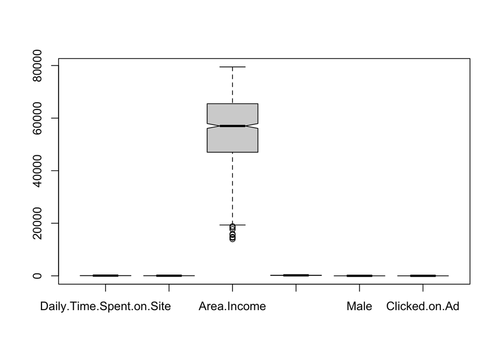

```r
boxplot(num_cols, notch = TRUE)
```

### let’s see the values which are outliers in the Area.Income variable

```r
boxplot.stats(adverts$Area.Income)$out
```

```
## [1] 17709.98 18819.34 15598.29 15879.10 14548.06 13996.50 14775.50 18368.57
```

### let’s check for outliers using Z-SCORES

### The z-score indicates the number of standard deviations a given value deviates from the mean.

```r
z_scores <- as.data.frame(sapply(num_cols, function(num_cols) (abs(num_cols-mean(num_cols))/sd(num_cols))))
z_scores
```

| Daily.Time.Spent.on.Site | Age | Area.Income | Daily.Internet.Usage | Male | Clicked.on.Ad |
| --- | --- | --- | --- | --- | --- |
| 0.249141922 | 0.114847515 | 0.5094361806 | 1.733162770 | 0.9622138 | 0.9994999 |
| 0.960651587 | 0.570139944 | 1.0020288215 | 0.313648435 | 1.0382307 | 0.9994999 |
| 0.281942013 | 1.139255479 | 0.3567700701 | 1.286945090 | 0.9622138 | 0.9994999 |
| 0.577142831 | 0.797786158 | 0.0144484061 | 1.500828909 | 1.0382307 | 0.9994999 |
| 0.212557205 | 0.114847515 | 1.4081628980 | 1.038211192 | 0.9622138 | 0.9994999 |
| 0.316028876 | 1.480724801 | 0.3549526519 | 1.064633474 | 1.0382307 | 0.9994999 |
| 1.508160798 | 0.342493729 | 0.0855148249 | 0.645976967 | 0.9622138 | 0.9994999 |
| 0.063064483 | 1.364852878 | 2.2666790633 | 1.098804774 | 1.0382307 | 0.9994999 |
| 0.601112129 | 0.683963051 | 1.0333490945 | 0.945505425 | 1.0382307 | 0.9994999 |
| 0.307803623 | 1.822194122 | 0.0478820308 | 0.087009031 | 1.0382307 | 0.9994999 |

[output cut: 990 more lines]

###–>> We will drop values with a Z-Score of more than 3 or -3. They are the outliers

### Removing the outliers

```r
no_outliers <- z_scores[!rowSums(z_scores>3), ]
head(no_outliers)
```

|  | Daily.Time.Spent.on.Site | Age | Area.Income | Daily.Internet.Usage | Male | Clicked.on.Ad |
| --- | --- | --- | --- | --- | --- | --- |
| 1 | 0.2491419 | 0.1148475 | 0.50943618 | 1.7331628 | 0.9622138 | 0.9994999 |
| 2 | 0.9606516 | 0.5701399 | 1.00202882 | 0.3136484 | 1.0382307 | 0.9994999 |
| 3 | 0.2819420 | 1.1392555 | 0.35677007 | 1.2869451 | 0.9622138 | 0.9994999 |
| 4 | 0.5771428 | 0.7977862 | 0.01444841 | 1.5008289 | 1.0382307 | 0.9994999 |
| 5 | 0.2125572 | 0.1148475 | 1.40816290 | 1.0382112 | 0.9622138 | 0.9994999 |
| 6 | 0.3160289 | 1.4807248 | 0.35495265 | 1.0646335 | 1.0382307 | 0.9994999 |

### let’s check the number of observations after removing outliers

```r
dim(num_cols)
```

```
## [1] 1000    6
```

```r
dim(no_outliers)
```

```
## [1] 998   6
```

###–>> We removed 2 observations.

### let’s check for outliers in the new dataframe after removing them

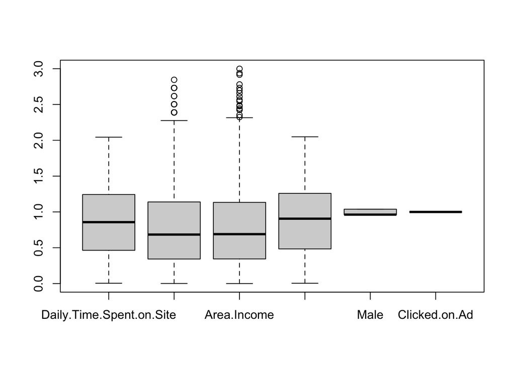

```r
boxplot(no_outliers)
```

###–>> There are still outliers so we will use interquantile range method to remove outliers

### checking and removing outliers using IQR

### The Area.Income column had outliers so we focus on it

```r
# Apply the Interquartile Range, IQR(), function on the area income column
income.IQR <- 65471-47032
income.IQR <-IQR(adverts$`Area.Income`)
income.IQR
```

```
## [1] 18438.83
```

### let’s save the dataframe without outliers into a new dataframe by assigning it to a variable

```r
adverts_2 <- subset(adverts, adverts$`Area.Income`> (47032 - 1.5*income.IQR) & adverts$`Area.Income`<(65471 + 1.5*income.IQR))
```

### let’s see the shape of the new dataframe

```r
dim(adverts_2)
```

```
## [1] 991  10
```

###–>> We have lost 9 observations that included the outliers. We proceed with analysis.

# ### 4. {UNIVARIATE ANALYSIS}

### let’s get the mean of the numerical columns

```r
summary(num_cols)
```

```
##  Daily.Time.Spent.on.Site      Age         Area.Income    Daily.Internet.Usage
##  Min.   :32.60            Min.   :19.00   Min.   :13996   Min.   :104.8
##  1st Qu.:51.36            1st Qu.:29.00   1st Qu.:47032   1st Qu.:138.8
##  Median :68.22            Median :35.00   Median :57012   Median :183.1
##  Mean   :65.00            Mean   :36.01   Mean   :55000   Mean   :180.0
##  3rd Qu.:78.55            3rd Qu.:42.00   3rd Qu.:65471   3rd Qu.:218.8
##  Max.   :91.43            Max.   :61.00   Max.   :79485   Max.   :270.0
##       Male       Clicked.on.Ad
##  Min.   :0.000   Min.   :0.0
##  1st Qu.:0.000   1st Qu.:0.0
##  Median :0.000   Median :0.5
##  Mean   :0.481   Mean   :0.5
##  3rd Qu.:1.000   3rd Qu.:1.0
##  Max.   :1.000   Max.   :1.0
```

###–>> The summary shows: ###–>> 1. The minimum value for each numerical variable. ###–>> 2. The first quantile for each numerical variable ###–>> 3. The median value for all numeric variables across the dataframe. ###–>> 4. The mean value for all numeric variables. ###–>> 5. The third quantile. ###–>> 6. The maximum value for all numerical columns.

### let’s get the variance for the numeric variables

```r
variance <- var(num_cols)
variance
```

```
##                          Daily.Time.Spent.on.Site           Age   Area.Income
## Daily.Time.Spent.on.Site              251.3370949 -4.617415e+01  6.613081e+04
## Age                                   -46.1741459  7.718611e+01 -2.152093e+04
## Area.Income                         66130.8109082 -2.152093e+04  1.799524e+08
## Daily.Internet.Usage                  360.9918827 -1.416348e+02  1.987625e+05
## Male                                   -0.1501864 -9.242142e-02  8.867509e+00
## Clicked.on.Ad                          -5.9331431  2.164665e+00 -3.195989e+03
##                          Daily.Internet.Usage        Male Clicked.on.Ad
## Daily.Time.Spent.on.Site         3.609919e+02 -0.15018639 -5.933143e+00
## Age                             -1.416348e+02 -0.09242142  2.164665e+00
## Area.Income                      1.987625e+05  8.86750903 -3.195989e+03
## Daily.Internet.Usage             1.927415e+03  0.61476667 -1.727409e+01
## Male                             6.147667e-01  0.24988889 -9.509510e-03
## Clicked.on.Ad                   -1.727409e+01 -0.00950951  2.502503e-01
```

###–>> variance is a measure of how far the set of data points per column is spread out from their mean eg. those of the area income seem to be far spread out from their mean when compared to that of the age column.

### let’s get the standard deviation of the numeric variables

### let’s create a function to get the standard deviations

```r
sd.function <- function(column) {
  standard.deviations <- sd(column)
  print(standard.deviations)
}
```

### standard deviation for daily time spent on site

```r
sd.function(adverts_2$Daily.Time.Spent.on.Site)
```

```
## [1] 15.9005
```

### standard deviation for Age

```r
sd.function(adverts_2$Age)
```

```
## [1] 8.804716
```

### standard deviation for Area.Income

```r
sd.function(adverts_2$Area.Income)
```

```
## [1] 12961.5
```

### standard deviation for Daily.Internet.Usage

```r
sd.function(adverts_2$Daily.Internet.Usage)
```

```
## [1] 44.05386
```

###–>> Where a low standard deviation indicates that values are closer to the mean a high one indicates the standard deviation is far from the mean e.g the age column standard deviation of 8.8 displays that its values are closer to their mean than that of the Area income column whose value is 12961

### let’s get the skewness of the numerical column

```r
library(moments)
skewness(num_cols)
```

```
## Daily.Time.Spent.on.Site                      Age              Area.Income
##              -0.37120261               0.47842268              -0.64939670
##     Daily.Internet.Usage                     Male            Clicked.on.Ad
##              -0.03348703               0.07605493               0.00000000
```

# ### 5. {BIVARIATE ANALYSIS}

### let’s get the covariance of the numeric variables

```r
cov(num_cols)
```

```
##                          Daily.Time.Spent.on.Site           Age   Area.Income
## Daily.Time.Spent.on.Site              251.3370949 -4.617415e+01  6.613081e+04
## Age                                   -46.1741459  7.718611e+01 -2.152093e+04
## Area.Income                         66130.8109082 -2.152093e+04  1.799524e+08
## Daily.Internet.Usage                  360.9918827 -1.416348e+02  1.987625e+05
## Male                                   -0.1501864 -9.242142e-02  8.867509e+00
## Clicked.on.Ad                          -5.9331431  2.164665e+00 -3.195989e+03
##                          Daily.Internet.Usage        Male Clicked.on.Ad
## Daily.Time.Spent.on.Site         3.609919e+02 -0.15018639 -5.933143e+00
## Age                             -1.416348e+02 -0.09242142  2.164665e+00
## Area.Income                      1.987625e+05  8.86750903 -3.195989e+03
## Daily.Internet.Usage             1.927415e+03  0.61476667 -1.727409e+01
## Male                             6.147667e-01  0.24988889 -9.509510e-03
## Clicked.on.Ad                   -1.727409e+01 -0.00950951  2.502503e-01
```

###–>> The age variable is the only column with a positive covariance with the ad click variable, the rest have negative covariances.

### let’s get the correlation coefficient

```r
cor(num_cols)
```

```
##                          Daily.Time.Spent.on.Site         Age  Area.Income
## Daily.Time.Spent.on.Site               1.00000000 -0.33151334  0.310954413
## Age                                   -0.33151334  1.00000000 -0.182604955
## Area.Income                            0.31095441 -0.18260496  1.000000000
## Daily.Internet.Usage                   0.51865848 -0.36720856  0.337495533
## Male                                  -0.01895085 -0.02104406  0.001322359
## Clicked.on.Ad                         -0.74811656  0.49253127 -0.476254628
##                          Daily.Internet.Usage         Male Clicked.on.Ad
## Daily.Time.Spent.on.Site           0.51865848 -0.018950855   -0.74811656
## Age                               -0.36720856 -0.021044064    0.49253127
## Area.Income                        0.33749553  0.001322359   -0.47625463
## Daily.Internet.Usage               1.00000000  0.028012326   -0.78653918
## Male                               0.02801233  1.000000000   -0.03802747
## Clicked.on.Ad                     -0.78653918 -0.038027466    1.00000000
```

###–>> The variables have a negative correlation with the target variable apart from the age variable which has a positive correlation. Let’s see that in the correlogram below

### let’s see the corrplot of the numeric variables

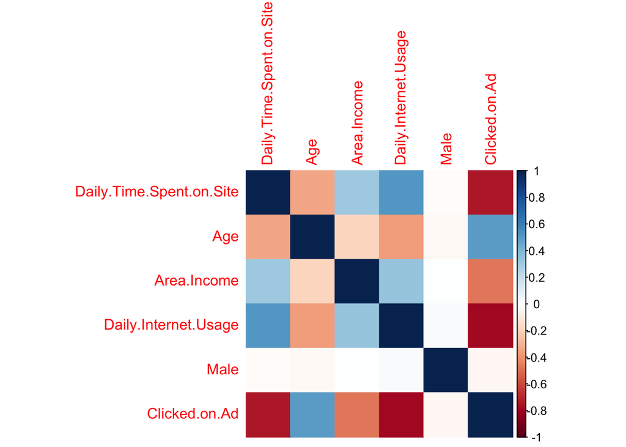

```r
library(corrplot)
corr_ <- cor(num_cols)

corrplot(corr_, method = 'color')
```

# ### {RECOMMENDATIONS}